# Descriptive Project_ Group_6

# Loading Necessary Packages

```r
library(tidyverse)
```

# Read csv files into R environment

```r
main_data <- read_csv("~/Desktop/Engg_Management/Descriptive_Analysis(621)/Project/ObesityDataSet_raw_and_data_sinthetic 2.csv",show_col_types = FALSE)
main_data
```

| Gender | Age | Height | Weight | family_history_with_overweight | FAVC | FCVC | NCP | CAEC | SMOKE | CH2O | SCC | FAF | TUE | CALC | MTRANS | NObeyesdad |
| --- | --- | --- | --- | --- | --- | --- | --- | --- | --- | --- | --- | --- | --- | --- | --- | --- |
| Female | 21.00000 | 1.620000 | 64.00000 | yes | no | 2.000000 | 3.000000 | Sometimes | no | 2.000000 | no | 0.000000 | 1.000000 | no | Public_Transportation | Normal_Weight |
| Female | 21.00000 | 1.520000 | 56.00000 | yes | no | 3.000000 | 3.000000 | Sometimes | yes | 3.000000 | yes | 3.000000 | 0.000000 | Sometimes | Public_Transportation | Normal_Weight |
| Male | 23.00000 | 1.800000 | 77.00000 | yes | no | 2.000000 | 3.000000 | Sometimes | no | 2.000000 | no | 2.000000 | 1.000000 | Frequently | Public_Transportation | Normal_Weight |
| Male | 27.00000 | 1.800000 | 87.00000 | no | no | 3.000000 | 3.000000 | Sometimes | no | 2.000000 | no | 2.000000 | 0.000000 | Frequently | Walking | Overweight_Level_I |
| Male | 22.00000 | 1.780000 | 89.80000 | no | no | 2.000000 | 1.000000 | Sometimes | no | 2.000000 | no | 0.000000 | 0.000000 | Sometimes | Public_Transportation | Overweight_Level_II |
| Male | 29.00000 | 1.620000 | 53.00000 | no | yes | 2.000000 | 3.000000 | Sometimes | no | 2.000000 | no | 0.000000 | 0.000000 | Sometimes | Automobile | Normal_Weight |
| Female | 23.00000 | 1.500000 | 55.00000 | yes | yes | 3.000000 | 3.000000 | Sometimes | no | 2.000000 | no | 1.000000 | 0.000000 | Sometimes | Motorbike | Normal_Weight |
| Male | 22.00000 | 1.640000 | 53.00000 | no | no | 2.000000 | 3.000000 | Sometimes | no | 2.000000 | no | 3.000000 | 0.000000 | Sometimes | Public_Transportation | Normal_Weight |
| Male | 24.00000 | 1.780000 | 64.00000 | yes | yes | 3.000000 | 3.000000 | Sometimes | no | 2.000000 | no | 1.000000 | 1.000000 | Frequently | Public_Transportation | Normal_Weight |
| Male | 22.00000 | 1.720000 | 68.00000 | yes | yes | 2.000000 | 3.000000 | Sometimes | no | 2.000000 | no | 1.000000 | 1.000000 | no | Public_Transportation | Normal_Weight |

[output cut: 990 more lines]

# Exploratory Data Analysis

# Check for missing values within the data set

```r
missing_values <- sum(is.na(main_data))
print(paste("Missing Values in the dataset:" ,missing_values))
```

```
[1] "Missing Values in the dataset: 0"
```

# List of overall variables used in the analysis:

1.Calorie Monitoring (SCC): Binary (Categorical: YES/NO) – Indicates whether the individual monitors their calorie intake.

2.Frequency of Physical Activity (FAF): Continuous (Numerical) – Represents the frequency at which an individual engages in physical activity.

4.Age (age): Continuous (Numerical) – Represents the age of the individual.

# Research Question 1:

What is the relationship between calorie monitoring and obesity levels?

# 1.1 Variables used for analysis:

Independent Variable = Calorie Monitoring (SCC) – Binary Dependent Variable: Obesity Level (NObeyesdad) – Categorical

# 1.2 Defining Hypotheses for the following analysis:

1. Null Hypotheses , Ho = There is no relationship between monitoring caloric intake and obesity levels. (Caloric monitoring is independent of obesity level.)
2. Alternate Hypotheses , H1 = There is a relationship between monitoring caloric intake and obesity levels. (Caloric monitoring is dependent on obesity level.)

# 1.3 Chi-Squared Test of Independence

```r
Calorie_Monitoring_vs_Obsesity_levels <- table(main_data$SCC, main_data$NObeyesdad)
chisq_result_scc <- chisq.test(Calorie_Monitoring_vs_Obsesity_levels)
chisq_result_scc
```

```
    Pearson's Chi-squared test

data:  Calorie_Monitoring_vs_Obsesity_levels
X-squared = 123.02, df = 6, p-value < 2.2e-16
```

# 1.4 Explanation for the above analysis:

1. X- squared value depicts how much the observed data is deviated from the expected data under the assumption tht there isn’t any relationship between the variables
2. The p values is extremely small , such that it is smaller than the significance level of 0.05 (p<0.05). Due to which we reject the Null hypotheses.

Conclusion : Therefore the calorie monitoring is not independent of obesity levels. In other words, calorie monitoring is significantly associated with different obesity levels.

# 1.5 Visual Represenation of Calorie Monitoring vs Obesity Levels

# 1.6 Bar plot of Obesity level vs Calorie Monitoring

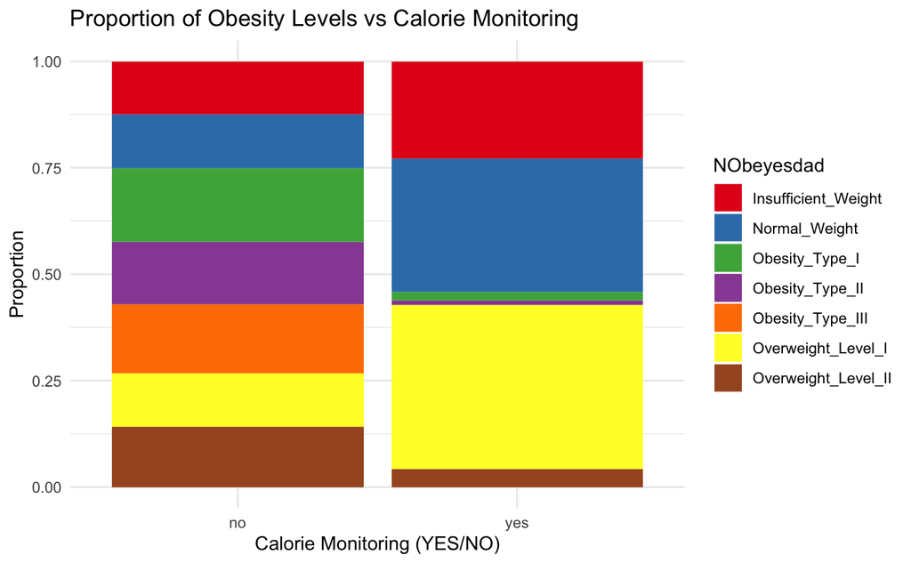

```r
ggplot(main_data, aes(x = SCC, fill = NObeyesdad)) +
  geom_bar(position = "fill") +
  labs(title = "Proportion of Obesity Levels vs Calorie Monitoring",
       x = "Calorie Monitoring (YES/NO)",
       y = "Proportion") +
  theme_minimal() +
  scale_fill_brewer(palette = "Set1")
```

# Research Question 2:

How does the frequency of physical activity impact obesity levels?

# 2.1 Variables used for analysis:

Independent Variable - Physical Activity -(FAF)- Continuous Dependent Variable: Obesity Level (NObeyesdad) – Categorical

# 2.2 Defining Hypotheses for the following analysis:

Null Hypothesis, Ho = Frequency of physical activity is independent of obesity levels Alternative Hypothesis, H1 = Frequency of physical activity is associated with obesity levels.

# 2.3 ANOVA for physical activity vs obesity levels

```r
anova_result_faf <- aov(FAF ~ NObeyesdad, data = main_data)
summary(anova_result_faf)
```

```
              Df Sum Sq Mean Sq F value Pr(>F)
NObeyesdad     6   72.5  12.084   17.48 <2e-16 ***
Residuals   2104 1454.1   0.691
---
Signif. codes:  0 ‘***’ 0.001 ‘**’ 0.01 ‘*’ 0.05 ‘.’ 0.1 ‘ ’ 1
```

# 2.4 Explanation for the above analysis:

1.F-Value (17.48): A large F-value indicates that the variation in obesity levels is significantly explained by the frequency of physical activity. 2.P-Value (<2e-16): Since the p-value is much less than 0.05, we reject the null hypothesis. 3. The triple asterisks (***) next to the p-value indicate a highly significant relationship, confirming that physical activity is a crucial factor in obesity management.

# 2.5 Visual Represenation of Physical activity vs Obesity Levels

# 2.6 Box Plot of Physical Activity vs Obesity Levels

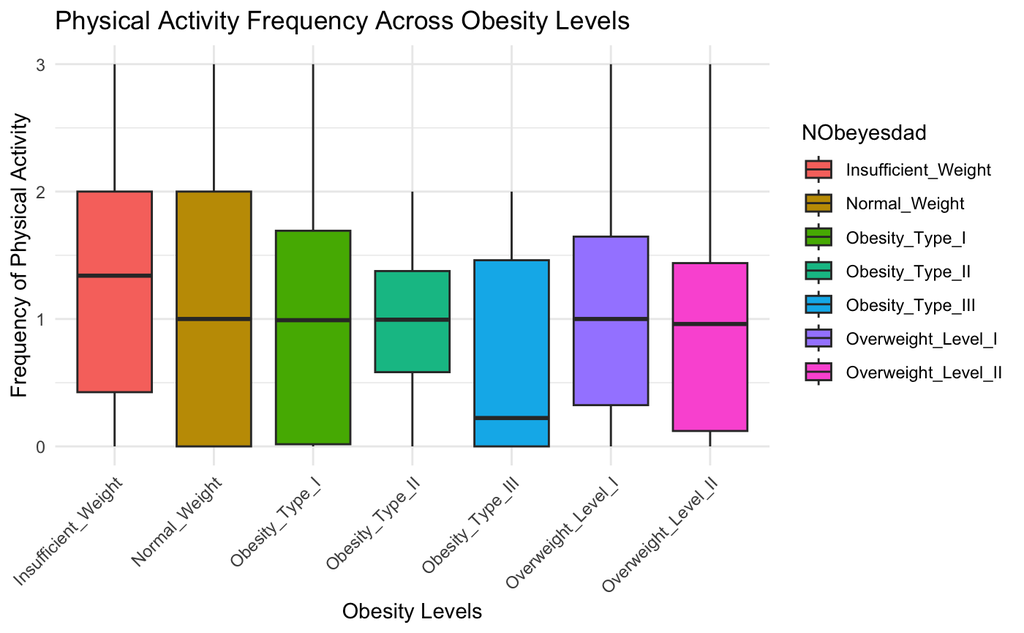

```r
ggplot(main_data, aes(x = NObeyesdad, y = FAF, fill = NObeyesdad)) +
  geom_boxplot() +
  labs(title = "Physical Activity Frequency Across Obesity Levels",
       x = "Obesity Levels",
       y = "Frequency of Physical Activity") +
  theme_minimal() +
  theme(axis.text.x = element_text(angle = 45, hjust = 1))
```

```r
NA
NA
```

# Research Question 3:

How does alcohol consumption relate to obesity levels?

# 3.1 Variables used for analysis:

Independent Variable = Alcohol Consumption (CALC) – Categorical Dependent Variable: Obesity Level (NObeyesdad) – Categorical

# 3.2 Defining Hypotheses for the following analysis:

1. Null Hypotheses , Ho = There is no relationship between alcohol consumption and obesity levels.
2. Alternate Hypotheses , H1 = Alcohol consumption is associated with obesity levels.

# 3.3. Chi-Squared Test of Independence (Alcohol Consumption vs Obesity)

```r
table_alcohol <- table(main_data$CALC, main_data$NObeyesdad)
chisq_result_alcohol <- chisq.test(table_alcohol)
chisq_result_alcohol
```

```
    Pearson's Chi-squared test

data:  table_alcohol
X-squared = 338.58, df = 18, p-value < 2.2e-16
```

# 3.4 Explanation for the above analysis:

1. Chi-Square Statistic (338.58): A large Chi-Square value indicates a significant deviation from what we would expect if there were no relationship between alcohol consumption and obesity levels. 2.p-value (< 2.2e-16): Since the p-value is extremely small (less than 0.001), it provides strong evidence to reject the null hypothesis

Conclusion: There is a statistically significant relationship between alcohol consumption and obesity levels. This suggests that the frequency or type of alcohol consumption is likely associated with varying obesity levels.

# 3.4 Visual Represenation of Proportion of Obesity level vs Alcohol Consumption

# 3.5. Bar Plot of Alcohol Consumption vs Obesity Levels

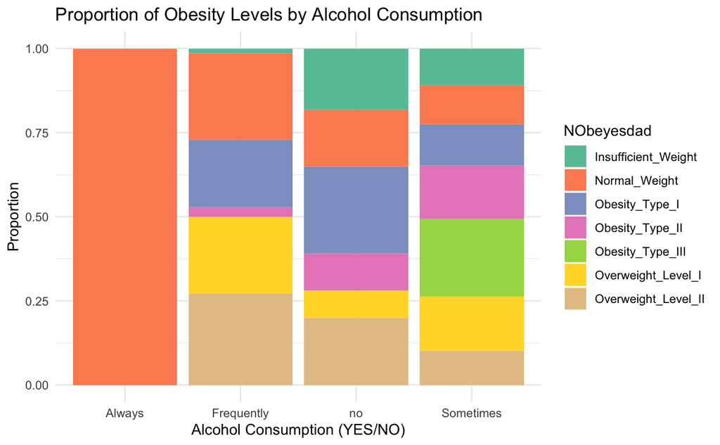

```r
ggplot(main_data, aes(x = CALC, fill = NObeyesdad)) +
  geom_bar(position = "fill") +
  labs(title = "Proportion of Obesity Levels by Alcohol Consumption",
       x = "Alcohol Consumption (YES/NO)",
       y = "Proportion") +
  theme_minimal() +
  scale_fill_brewer(palette = "Set2")
```